# YAPS - Yet Another Positioning Solver

### Results

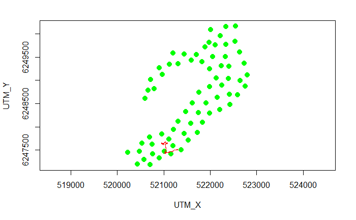

```r
# basic plotting
plotYaps(inp1335_rbi, yaps1335_rbi)
```

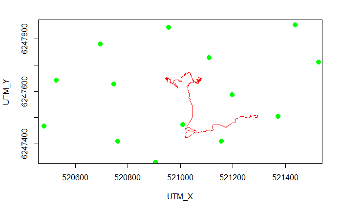

```r
# zoom in
plotYaps(inp1335_rbi, yaps1335_rbi, xlim=c(520500, 521500), ylim=c(6247400, 6247800))
```

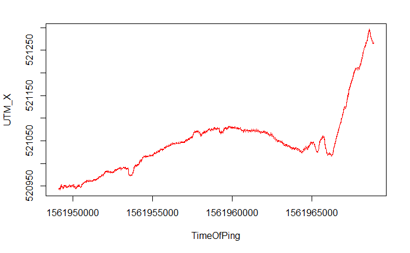

```r
plotYaps(inp1335_rbi, yaps1335_rbi, type="coord_X")
```

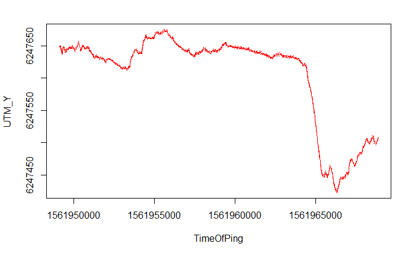

```r
plotYaps(inp1335_rbi, yaps1335_rbi, type="coord_Y")
```

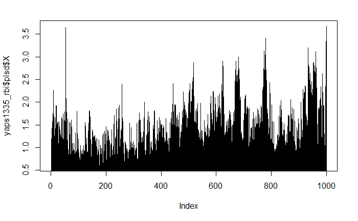

```r
# uncertainties... standard error of position estimates
plot(yaps1335_rbi$plsd$X, type="h")
```

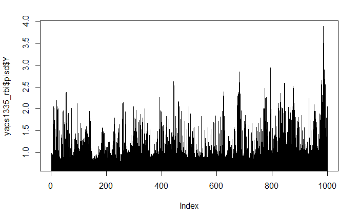

```r
plot(yaps1335_rbi$plsd$Y, type="h")
```

```r
# estimated speed of sound - sanity check
yaps1335_rbi$pl$ss
```

```
[1] 1471.674 1470.751 1456.088 1460.789 1460.256
```

```r
getSS(temp=c(15, 17))
```

```
[1] 1464.915 1470.967
```

```
default 'pch' is smaller than number of columns and hence recycled
```

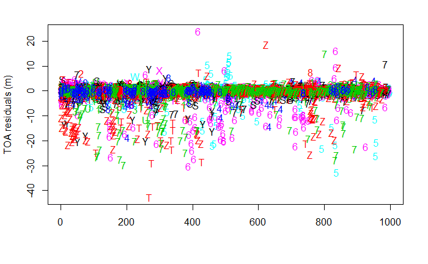

```r
# look at the residual
matplot(t((yaps1335_rbi$rep$mu_toa - inp1335_rbi$datTmb$toa))*1460, ylab="TOA residuals (m)")
```

## Tag 1335 - pike - random BI - utilizing **known** sequence

To utilize the known sequence of burst intervals, we need to align the observed data with the sequence. For this, we can use the function `alignBurstSeq()` from `yaps`. We can also take advantage of knowing the burst sequence when compiling the TOA-marix and we need extra info to feed into `getInp()`.

### Compiling the data

```r
dat1335 <- detections_synced[tag==1335]
ping_type <- 'pbi'
rbi_min <- 10
rbi_max <- 30

seq1335 <- hald$burst_seqs$seq1335 # just a long sequence of random numbers...
length(seq1335)
```

```
[1] 270460
```

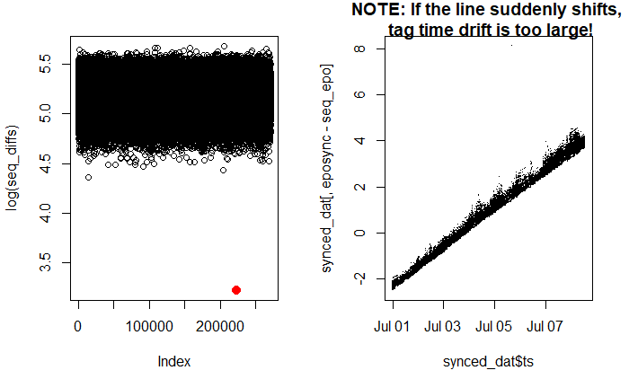

```r
dat1335_kbi <- alignBurstSeq(synced_dat=dat1335, burst_seq=seq1335, seq_lng_min=25, rbi_min=rbi_min, rbi_max=rbi_max, plot_diag=TRUE)
```

```r
toa1335_kbi_list <- buildToaKnownSeq(seq=seq1335, aligned_dat=dat1335_kbi, hydros=hydros_yaps)

toa1335_kbi <- toa1335_kbi_list$toa
seq1335_kbi <- toa1335_kbi_list$seq
```

More than 30 K pings will still take a long time to finish - we use the same subset as above.

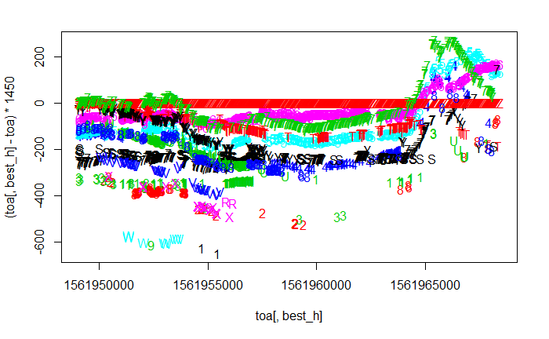

```r
ping_1 <- 501
n_ping <- 1000
toa1335_kbi_yaps <- toa1335_kbi[ping_1:(ping_1 + n_ping - 1), ]
biTable1335 <- seq1335_kbi[ping_1:(ping_1 + n_ping - 1) ]
plotToa(toa1335_kbi_yaps)
```

```r
plotNobs(toa1335_kbi_yaps)
```

### Get inp and run YAPS

Note, that ping_type now is `'pbi'`and we include the BItable in `getInp()`. Everything else is the same as above.

```r
inp1335_kbi <- getInp(toa=toa1335_kbi_yaps, hydros=hydros_yaps, E_dist="t", n_ss=5, pingType=ping_type, rbi_min=rbi_min, rbi_max=rbi_max, sdInits=1, ss_data_what="est", ss_data=0, biTable=biTable1335)

yaps1335_kbi <- runYaps(inp1335_kbi, maxIter=500, getPlsd=TRUE, getRep=TRUE, silent=TRUE)
```

```
[1] "Running yaps..."
[1] "...yaps converged (obj: -20567.6155272735)"
```

### Results

Quick look at the results

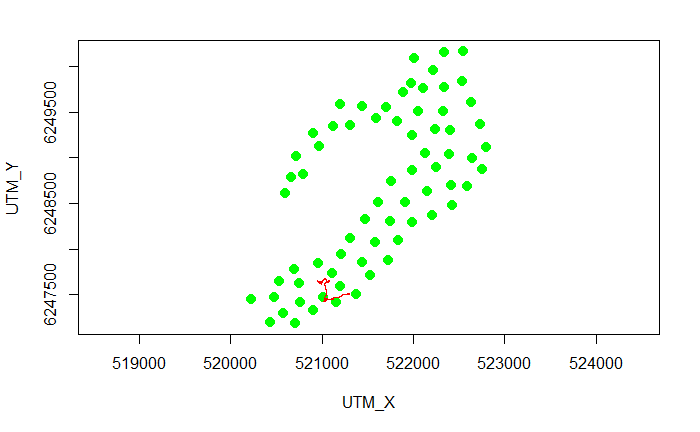

```r
# basic plotting
plotYaps(inp1335_kbi, yaps1335_kbi)
```

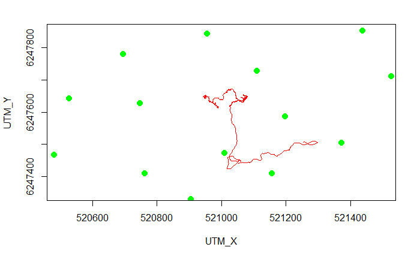

```r
# zoom in
plotYaps(inp1335_kbi, yaps1335_kbi, xlim=c(520500, 521500), ylim=c(6247400, 6247800))
```

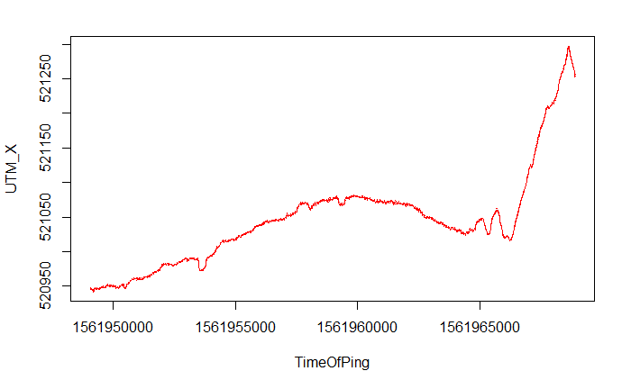

```r
plotYaps(inp1335_kbi, yaps1335_kbi, type="coord_X")
```

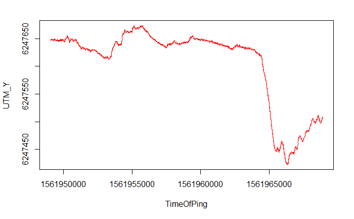

```r
plotYaps(inp1335_kbi, yaps1335_kbi, type="coord_Y")
```

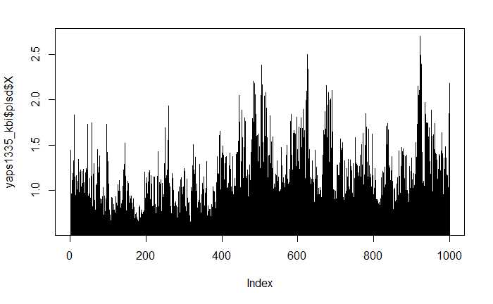

```r
# uncertainties... standard error of position estimates
plot(yaps1335_kbi$plsd$X, type="h")
```

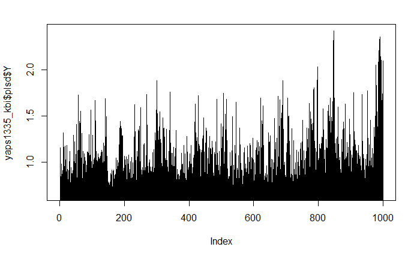

```r
plot(yaps1335_kbi$plsd$Y, type="h")
```

```r
# estimated speed of sound - sanity check
yaps1335_kbi$pl$ss
```

```
[1] 1470.799 1470.685 1458.900 1457.941 1461.038
```

```r
getSS(temp=c(15, 17))
```

```
[1] 1464.915 1470.967
```

```
default 'pch' is smaller than number of columns and hence recycled
```

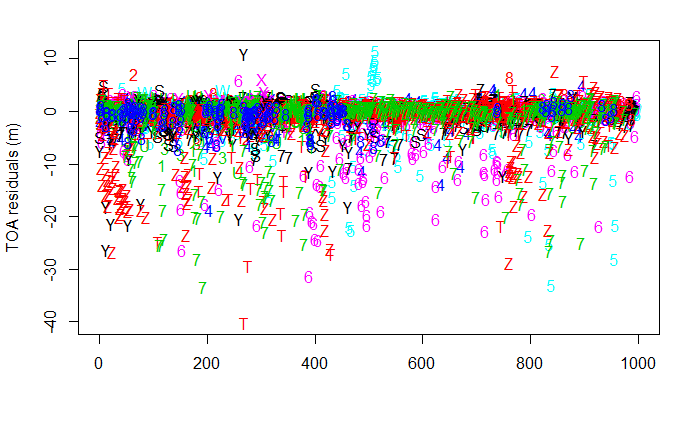

```r
# look at the residual
matplot(t((yaps1335_kbi$rep$mu_toa - inp1335_kbi$datTmb$toa))*1460, ylab="TOA residuals (m)")
```

### Tag 1335 pike - downsampling max_hydro <- 3

Knowing the burst interval sequence, gives opportunity to estimate tracks even when data density is low.

```r
ping_type <- 'pbi'

plotNobs(toa1335_kbi_yaps)
```

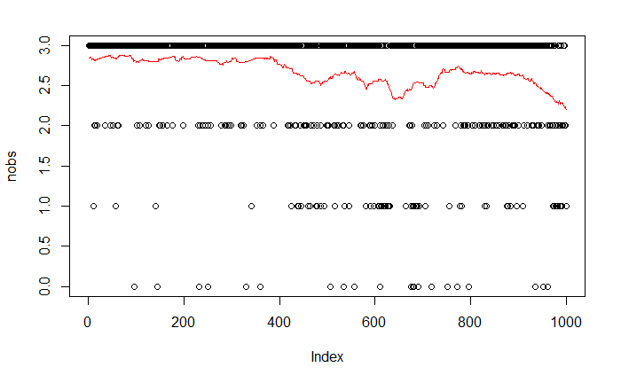

```r
max_hydro <- 3
toa1335_kbi_down3 <- downSampleToa(toa1335_kbi_yaps, max_hydro)
```

```r
inp1335_kbi_down3 <- getInp(toa=toa1335_kbi_down3, hydros=hydros_yaps, E_dist="t", n_ss=5, pingType=ping_type, rbi_min=rbi_min, rbi_max=rbi_max, sdInits=1, ss_data_what="est", ss_data=0, biTable=biTable1335)

yaps1335_kbi_down3 <- runYaps(inp1335_kbi_down3, maxIter=500, getPlsd=TRUE, getRep=TRUE, silent=TRUE)
```

```
[1] "Running yaps..."
[1] "...yaps converged (obj: -11767.9692842472)"
```

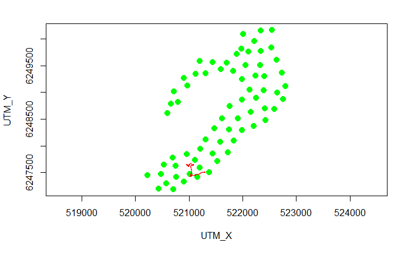

```r
plotYaps(inp1335_kbi_down3, yaps1335_kbi_down3)
```

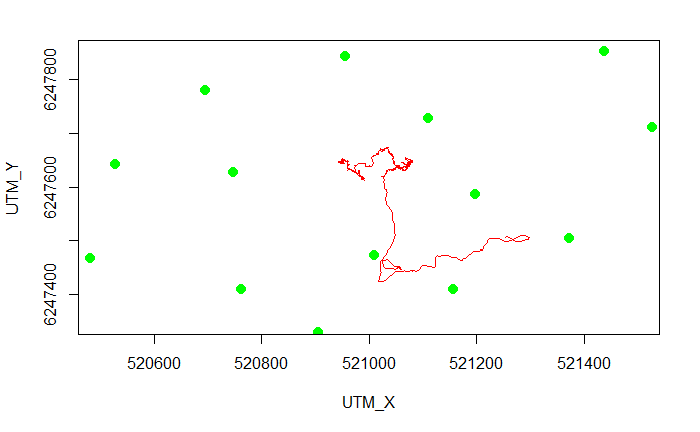

```r
# zoom in
plotYaps(inp1335_kbi_down3, yaps1335_kbi_down3, xlim=c(520500, 521500), ylim=c(6247400, 6247800))
```

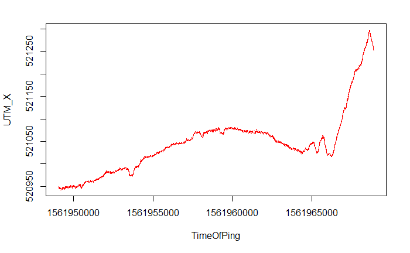

```r
plotYaps(inp1335_kbi_down3, yaps1335_kbi_down3, type="coord_X")
```

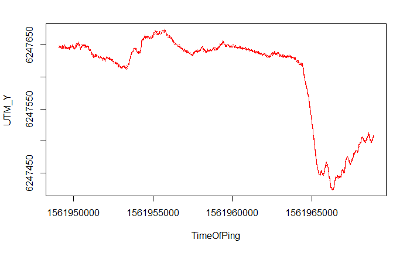

```r
plotYaps(inp1335_kbi_down3, yaps1335_kbi_down3, type="coord_Y")
```

### Tag 1335 pike - downsampling max_hydro <- 1

Trying at very low data density

```r
ping_type <- 'pbi'

plotNobs(toa1335_kbi_yaps)
```

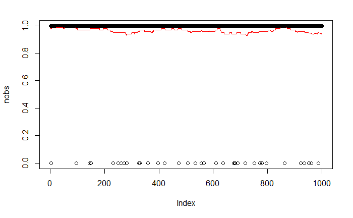

```r
max_hydro <- 1
toa1335_kbi_down1 <- downSampleToa(toa1335_kbi_yaps, max_hydro)
```

```r
inp1335_kbi_down1 <- getInp(toa=toa1335_kbi_down1, hydros=hydros_yaps, E_dist="t", n_ss=5, pingType=ping_type, rbi_min=rbi_min, rbi_max=rbi_max, sdInits=1, ss_data_what="est", ss_data=0, biTable=biTable1335)

yaps1335_kbi_down1 <- runYaps(inp1335_kbi_down1, maxIter=500, getPlsd=TRUE, getRep=TRUE, silent=TRUE)
```

```
[1] "Running yaps..."
[1] "...yaps converged (obj: -3884.74642191485)"
```

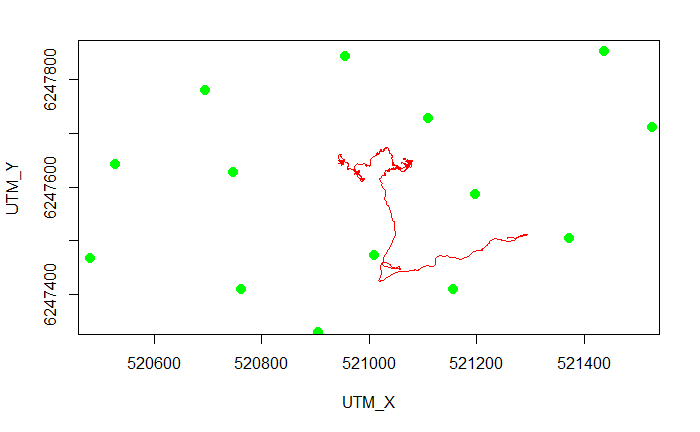

```r
# zoom in
plotYaps(inp1335_kbi_down1, yaps1335_kbi_down1, xlim=c(520500, 521500), ylim=c(6247400, 6247800))
```

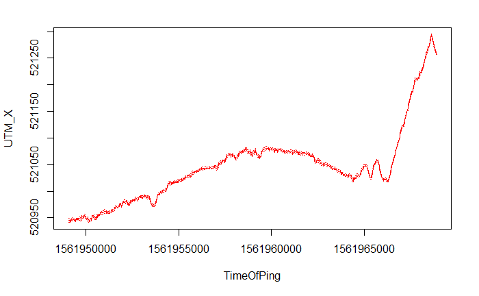

```r
plotYaps(inp1335_kbi_down1, yaps1335_kbi_down1, type="coord_X")
```

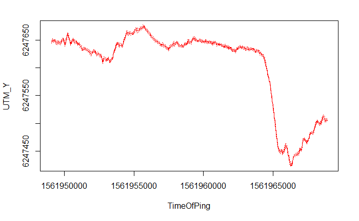

```r
plotYaps(inp1335_kbi_down1, yaps1335_kbi_down1, type="coord_Y")
```

### Comparing secret vs known BI sequences

```r
par(mfrow=c(2,3))
ylim=c(0,5)
plot(yaps1335_kbi$plsd$X, type="h", ylim=ylim)
plot(yaps1335_kbi_down1$plsd$X, type="h", ylim=ylim)
```

```r
plot(yaps1335_rbi$plsd$X, type="h", ylim=ylim)
plot(yaps1335_kbi$plsd$Y, type="h", ylim=ylim)
```

```r
plot(yaps1335_kbi_down1$plsd$Y, type="h", ylim=ylim)
plot(yaps1335_rbi$plsd$Y, type="h", ylim=ylim)
```

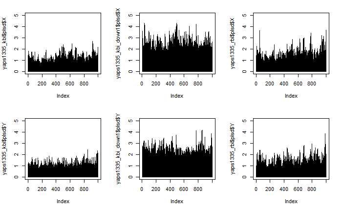

```r
par(mfrow=c(1,1))
```

### Tag 1335 - the full track

The full track can be estimated using this code:

```r
ping_type <- 'pbi'
rbi_min <- 10
rbi_max <- 30
seq1335 <- hald$burst_seqs$seq1335 # just a long sequence of random numbers...
dat1335_kbi <- alignBurstSeq(synced_dat=dat1335, burst_seq=seq1335, seq_lng_min=10, rbi_min=rbi_min, rbi_max=rbi_max, plot_diag=TRUE)
toa1335_kbi_list <- buildToaKnownSeq(seq=seq1335, aligned_dat=dat1335_kbi, hydros=hydros_yaps)
toa1335_kbi <- toa1335_kbi_list$toa
seq1335_kbi <- toa1335_kbi_list$seq
biTable1335 <- seq1335_kbi

ping_1 <- 1
n_ping <- nrow(toa1335_kbi)
toa1335_kbi_yaps <- toa1335_kbi[ping_1:(ping_1 + n_ping - 1), ]
biTable1335 <- seq1335_kbi[ping_1:(ping_1 + n_ping - 1) ]
plotToa(toa1335_kbi_yaps)
plotNobs(toa1335_kbi_yaps)

inp1335_kbi <- getInp(toa=toa1335_kbi_yaps, hydros=hydros_yaps, E_dist="t", n_ss=5, pingType=ping_type, rbi_min=rbi_min, rbi_max=rbi_max, sdInits=1, ss_data_what="est", ss_data=0, biTable=biTable1335)
inp1335_kbi$inits[1] <- 1
yaps1335_kbi <- runYaps(inp1335_kbi, maxIter=1000, getPlsd=TRUE, getRep=TRUE, silent=FALSE)
```

Lazy people can just grab it here:

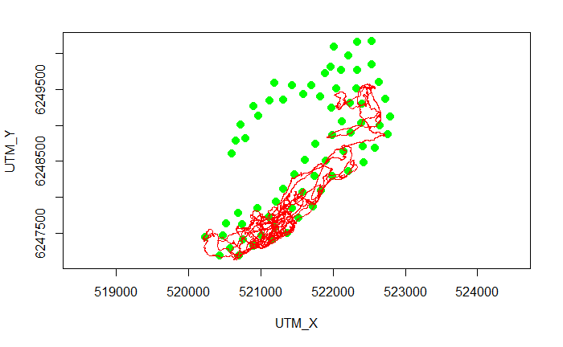

```r
load('../data/yaps1335_kbi_fullTrack.rObj')
plotYaps(inp1335_kbi, yaps1335_kbi)
```

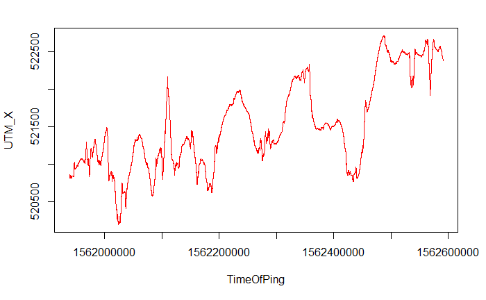

```r
plotYaps(inp1335_kbi, yaps1335_kbi, type="coord_X")
```

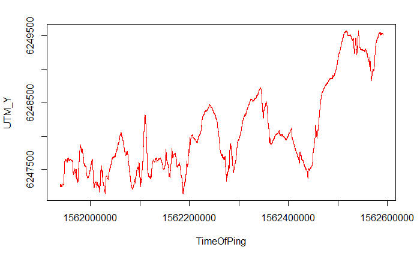

```r
plotYaps(inp1335_kbi, yaps1335_kbi, type="coord_Y")
```

## Tag 1315 - pike - random BI - assuming **secret** sequence

This transmitter is a random BI 60 - 120 s.

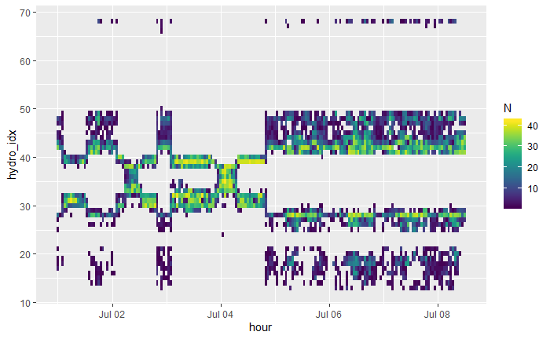

```r
dat1315 <- detections_synced[tag==1315]
rbi_min <- 60
rbi_max <- 120
dat1315[, hour := floor_date(ts, unit="hour")]
summ <- dat1315[, .N, by=c('hydro_idx', 'hour')]
ggplot(data=summ) + geom_tile(aes(x=hour, y=hydro_idx, fill=N)) + scale_fill_viridis()
```

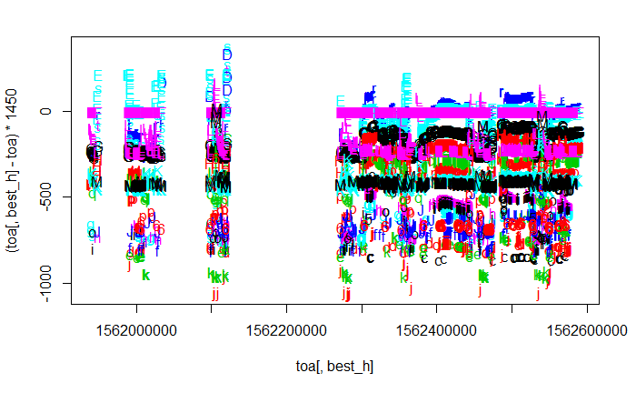

```r
# First, assume burst sequence is unknown
# Get TOA matrix for YAPS
ping_type <- 'rbi'
toa1315_rbi <- getToaYaps(synced_dat=dat1315, hydros=hydros_yaps, rbi_min=rbi_min, rbi_max=rbi_max)

# Have a look at the raw data...
plotToa(toa1315_rbi)
```

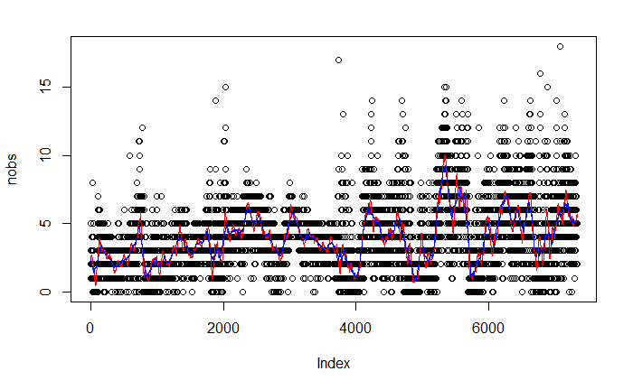

```r
plotNobs(toa1315_rbi)
```

```r
nobs <- getNobs(toa1315_rbi)
sum(nobs>=3) / length(nobs)
```

```
[1] 0.6914255
```

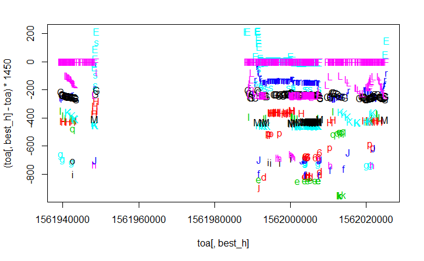

```r
# < 10.000 pings is doable, but we will sub sample to save time
ping_1 <- 1
n_ping <- 1000
toa1315_rbi_yaps <- toa1315_rbi[ping_1:(ping_1 + n_ping - 1), ]
plotToa(toa1315_rbi_yaps)
```

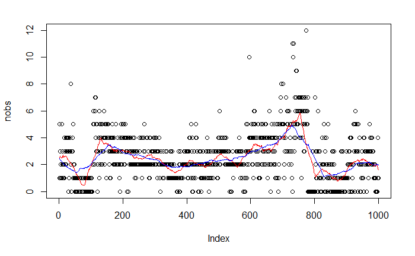

```r
plotNobs(toa1315_rbi_yaps)
```

```r
nobs <- getNobs(toa1315_rbi_yaps)
sum(nobs>=3) / length(nobs)
```

```
[1] 0.446
```

```r
# looks a bit more challenging than 1335
```

```r
# get inp to feed into YAPS and run YAPS
inp1315_rbi <- getInp(toa=toa1315_rbi_yaps, hydros=hydros_yaps, E_dist="t", n_ss=5, pingType=ping_type, rbi_min=rbi_min, rbi_max=rbi_max, sdInits=1, ss_data_what="est", ss_data=0, biTable=NULL)
inp1315_rbi$inits[1] <- 1
yaps1315_rbi <- runYaps(inp1315_rbi, maxIter=1000, getPlsd=TRUE, getRep=TRUE, silent=TRUE)
```

```
[1] "Running yaps..."
[1] "...yaps converged (obj: -666.318607884805)"
```

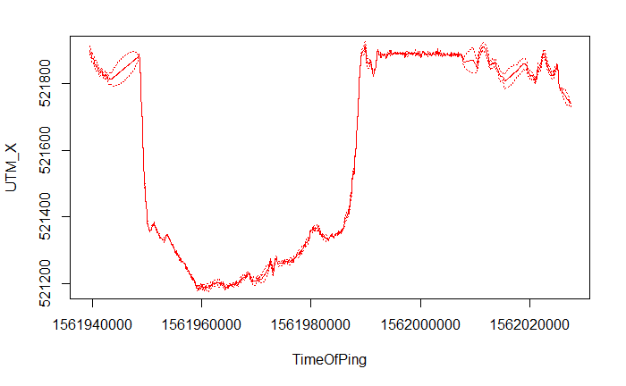

```r
# basic plotting
plotYaps(inp1315_rbi, yaps1315_rbi, type="coord_X")
```

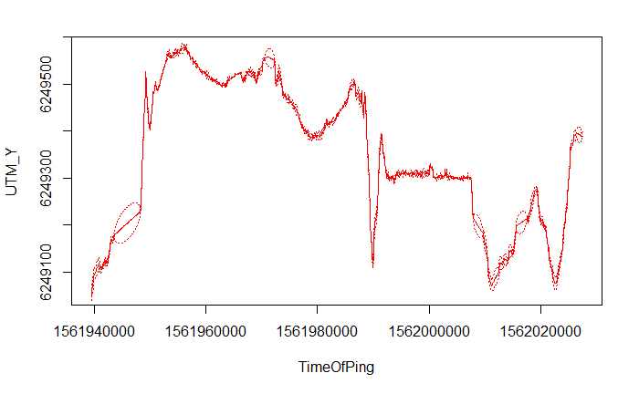

```r
plotYaps(inp1315_rbi, yaps1315_rbi, type="coord_Y")
```

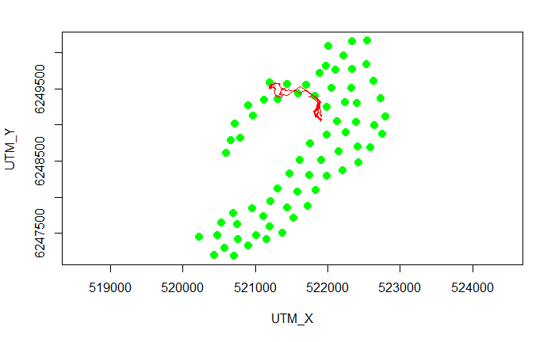

```r
plotYaps(inp1315_rbi, yaps1315_rbi)
```

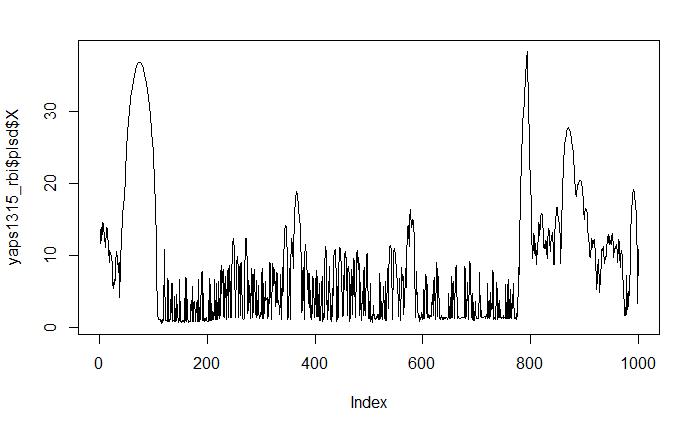

```r
# uncertainties... standard error of position estimates
plot(yaps1315_rbi$plsd$X, type="l")
```

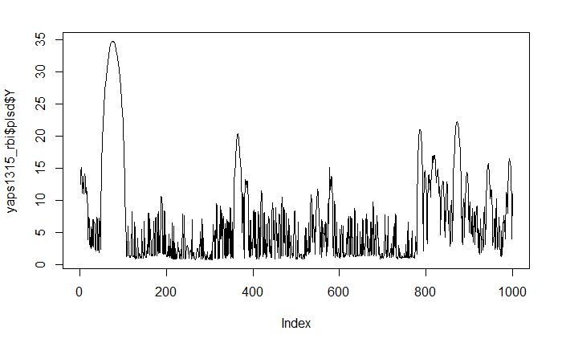

```r
plot(yaps1315_rbi$plsd$Y, type="l")
```

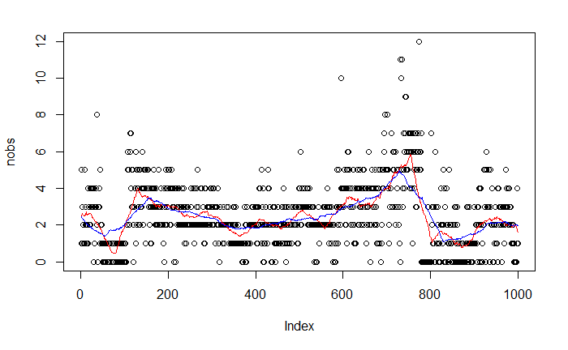

```r
plotNobs(toa1315_rbi_yaps)
```

```r
# estimated speed of sound - sanity check
yaps1315_rbi$pl$ss
```

```
[1] 1472.853 1472.384 1472.779 1474.695 1472.327
```

```
default 'pch' is smaller than number of columns and hence recycled
```

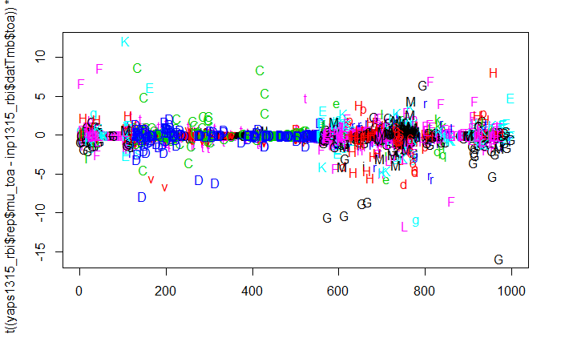

```r
# look at the residual
matplot(t((yaps1315_rbi$rep$mu_toa - inp1315_rbi$datTmb$toa))*1450)
```

## Tag 1315 - pike - random BI - utilizing **known** sequence

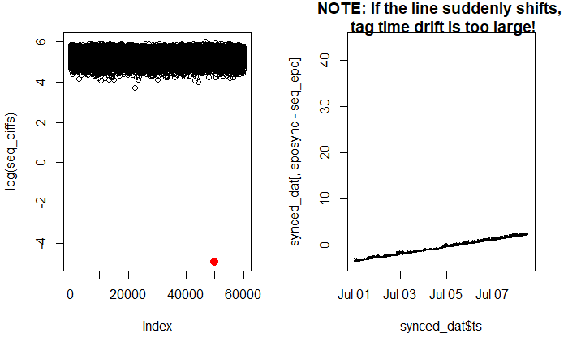

```r
ping_type <- 'pbi'
seq1315 <- hald$burst_seqs$seq1315 # just a long sequence of random numbers...

# we need to figure out where our data is on this sequence
dat1315_kbi <- alignBurstSeq(synced_dat=dat1315, burst_seq=seq1315, seq_lng_min=10, rbi_min=rbi_min, rbi_max=rbi_max, plot_diag=TRUE)
```

```r
toa1315_kbi_list <- buildToaKnownSeq(seq=seq1315, aligned_dat=dat1315_kbi, hydros=hydros_yaps)
str(toa1315_kbi_list)
```

```
List of 2
 $ toa: num [1:7241, 1:70] NA NA NA NA NA NA NA NA NA NA ...
 $ seq: int [1:7241] 119 104 91 96 120 87 80 117 118 99 ...
```

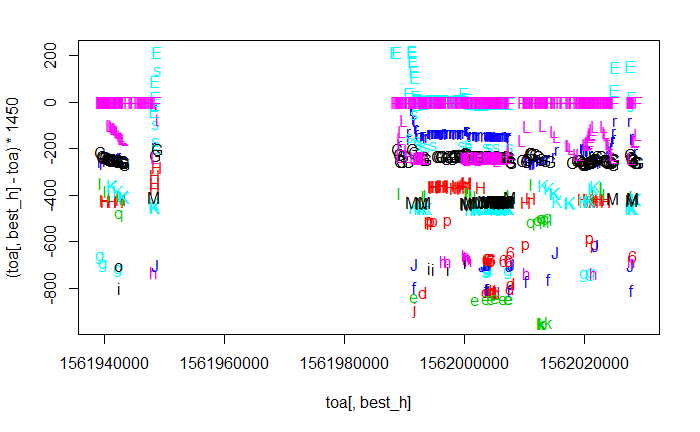

```r
toa1315_kbi <- toa1315_kbi_list$toa
seq1315_kbi <- toa1315_kbi_list$seq
biTable1315 <- seq1315_kbi

# subset data...
ping_1 <- 1
n_ping <- 1000
toa1315_kbi_yaps <- toa1315_kbi[ping_1:(ping_1 + n_ping - 1), ]
biTable1315 <- seq1315_kbi[ping_1:(ping_1 + n_ping - 1) ]
plotToa(toa1315_kbi_yaps)
```

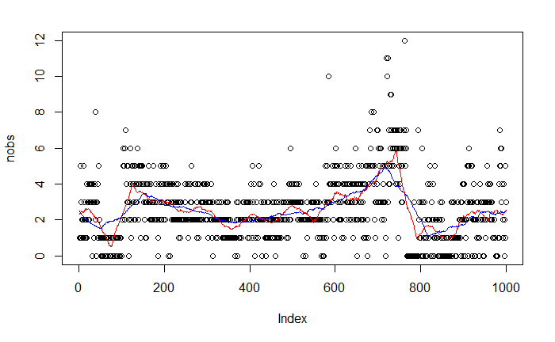

```r
plotNobs(toa1315_kbi_yaps)
```

```r
sum(getNobs(toa1315_kbi_yaps) >= 3) / nrow(toa1315_kbi_yaps)
```

```
[1] 0.457
```

```r
# get inp to feed into YAPS and run YAPS
inp1315_kbi <- getInp(toa=toa1315_kbi_yaps, hydros=hydros_yaps, E_dist="t", n_ss=5, pingType=ping_type, rbi_min=rbi_min, rbi_max=rbi_max, sdInits=1, ss_data_what="est", ss_data=0, biTable=biTable1315)
inp1315_kbi$inits[1] <- 1
yaps1315_kbi <- runYaps(inp1315_kbi, maxIter=1000, getPlsd=TRUE, getRep=TRUE, silent=TRUE)
```

```
[1] "Running yaps..."
[1] "...yaps converged (obj: -10244.7547317854)"
```

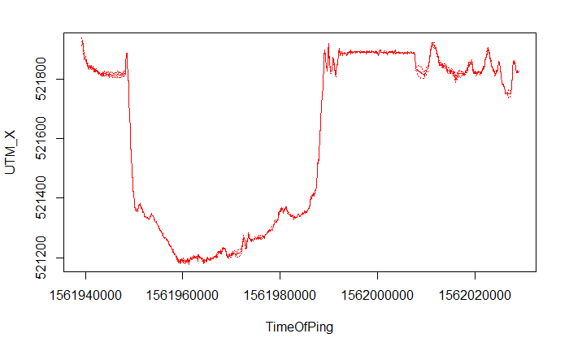

```r
# basic plotting
plotYaps(inp1315_kbi, yaps1315_kbi, type="coord_X")
```

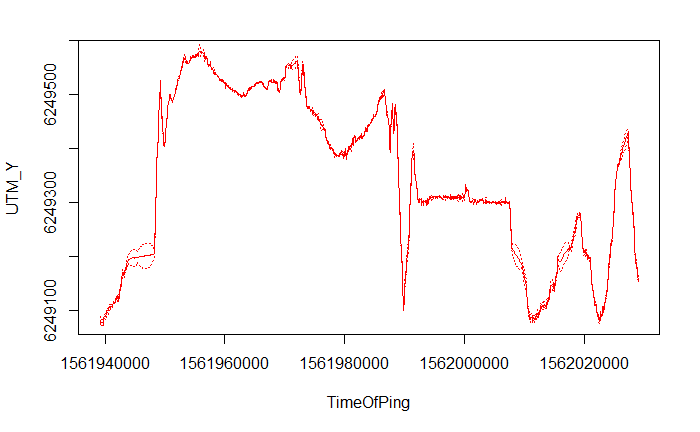

```r
plotYaps(inp1315_kbi, yaps1315_kbi, type="coord_Y")
```

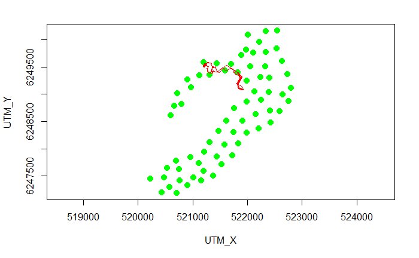

```r
plotYaps(inp1315_kbi, yaps1315_kbi)

# uncertainties... standard error of position estimates - compare to ping_type = 'rbi'
par(mfrow=c(2,2))
```

```r
ylim <- c(0,50)
plot(yaps1315_kbi$plsd$X, type="h", ylim=ylim)
plot(yaps1315_rbi$plsd$X, type="h", ylim=ylim)
```

```r
plot(yaps1315_kbi$plsd$Y, type="h", ylim=ylim)
plot(yaps1315_rbi$plsd$Y, type="h", ylim=ylim)
```

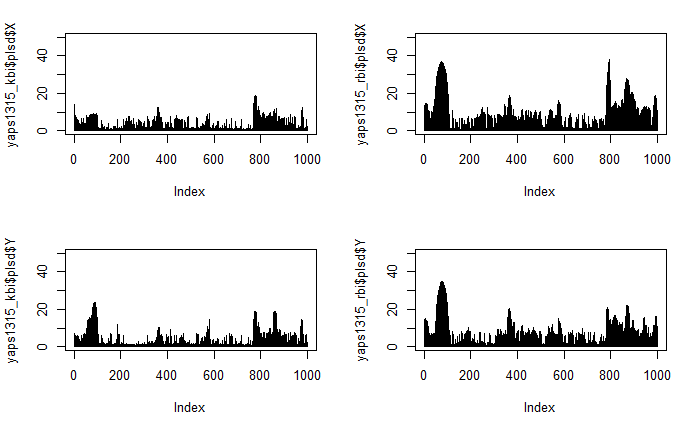

```r
par(mfrow=c(1,1))
```

### The full track

The full track can be estimated using this code - will probably take some 5 - 10 minutes.

```r
ping_type <- 'pbi'
rbi_min <- 60
rbi_max <- 120
seq1315 <- hald$burst_seqs$seq1315 # just a long sequence of random numbers...
dat1315_kbi <- alignBurstSeq(synced_dat=dat1315, burst_seq=seq1315, seq_lng_min=10, rbi_min=rbi_min, rbi_max=rbi_max, plot_diag=TRUE)
toa1315_kbi_list <- buildToaKnownSeq(seq=seq1315, aligned_dat=dat1315_kbi, hydros=hydros_yaps)
toa1315_kbi <- toa1315_kbi_list$toa
seq1315_kbi <- toa1315_kbi_list$seq
biTable1315 <- seq1315_kbi

ping_1 <- 1
n_ping <- nrow(toa1315_kbi)
toa1315_kbi_yaps <- toa1315_kbi[ping_1:(ping_1 + n_ping - 1), ]
biTable1315 <- seq1315_kbi[ping_1:(ping_1 + n_ping - 1) ]
plotToa(toa1315_kbi_yaps)
plotNobs(toa1315_kbi_yaps)

inp1315_kbi <- getInp(toa=toa1315_kbi_yaps, hydros=hydros_yaps, E_dist="t", n_ss=5, pingType=ping_type, rbi_min=rbi_min, rbi_max=rbi_max, sdInits=1, ss_data_what="est", ss_data=0, biTable=biTable1315)
inp1315_kbi$inits[1] <- 1
yaps1315_kbi <- runYaps(inp1315_kbi, maxIter=1000, getPlsd=TRUE, getRep=TRUE, silent=TRUE)
```

Lazy people can just grab it here:

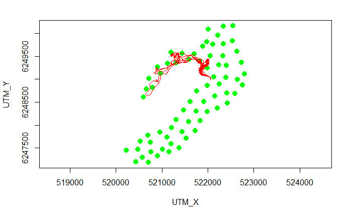

```r
load('../data/yaps1315_kbi_fullTrack.rObj')
plotYaps(inp1315_kbi, yaps1315_kbi)
```

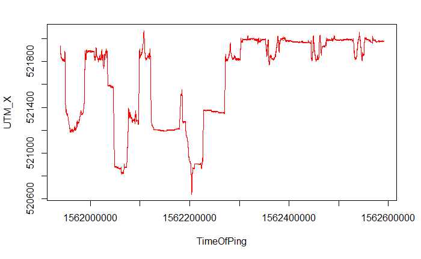

```r
plotYaps(inp1315_kbi, yaps1315_kbi, type="coord_X")
```

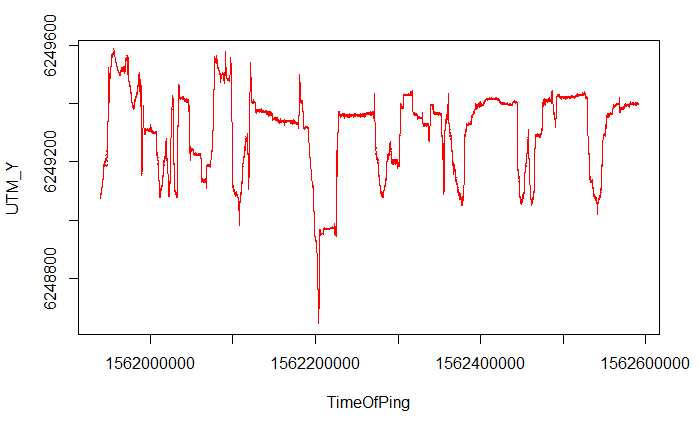

```r
plotYaps(inp1315_kbi, yaps1315_kbi, type="coord_Y")
```

# Appendix

## Obtaining the sync_model for the `hald` data

If you try to sync these data (which is encouraged), be aware of impossible sync tag - hydro combos. Also note that positions of hydro idx 32 and 70 are uncertain, so they sould be estimated, i.e. removed from the fixed_hydros_idx vector. These settings should give a good sync model

```r
    max_epo_diff <- 30
    min_hydros <- 5
    time_keeper_idx <- 1
    fixed_hydros_idx <- 1:70
    fixed_hydros_idx <- fixed_hydros_idx[!fixed_hydros_idx %in% c(32, 70)]
    n_offset_day <- 2
    n_ss_day <- 1
    inp_sync <- getInpSync(sync_dat, max_epo_diff, min_hydros, time_keeper_idx, fixed_hydros_idx, n_offset_day, n_ss_day, keep_rate=0.2)
    sync_model <- getSyncModel(inp_sync, silent=TRUE)
```